# Risk Factor Analysis

## Outcome Variable

**Outcome Variable:** whz

## Predictor Variables

**Intervention Variable:** nchldlt5

**Adjustment Set:**

- arm
- W_mage
- meducyrs
- feducyrs
- hhwealth_quart
- hfoodsec
- W_mhtcm
- W_mwtkg
- W_mbmi
- W_nrooms
- W_parity
- impfloor
- impsan
- safeh20
- delta_W_mage
- delta_meducyrs
- delta_feducyrs
- delta_hhwealth_quart
- delta_hfoodsec
- delta_W_mhtcm
- delta_W_mwtkg
- delta_W_mbmi
- delta_W_nrooms
- delta_W_parity
- delta_impfloor
- delta_impsan
- delta_safeh20

## Stratifying Variables

The analysis was stratified on these variable(s):

- agecat
- studyid
- country

## Data Summary

| agecat | studyid | country | nchldlt5 | n_cell | n |
| --- | --- | --- | --- | --- | --- |
| Birth | ki1000108-IRC | INDIA | 1 | 72 | 343 |
| Birth | ki1000108-IRC | INDIA | 2+ | 271 | 343 |
| Birth | ki1017093b-PROVIDE | BANGLADESH | 1 | 385 | 532 |
| Birth | ki1017093b-PROVIDE | BANGLADESH | 2+ | 147 | 532 |
| Birth | ki1017093c-NIH-Crypto | BANGLADESH | 1 | 504 | 707 |
| Birth | ki1017093c-NIH-Crypto | BANGLADESH | 2+ | 203 | 707 |
| Birth | kiGH5241-JiVitA-3 | BANGLADESH | 1 | 10878 | 17991 |
| Birth | kiGH5241-JiVitA-3 | BANGLADESH | 2+ | 7113 | 17991 |
| 6 months | ki1000108-IRC | INDIA | 1 | 88 | 408 |
| 6 months | ki1000108-IRC | INDIA | 2+ | 320 | 408 |
| 6 months | ki1017093b-PROVIDE | BANGLADESH | 1 | 438 | 603 |
| 6 months | ki1017093b-PROVIDE | BANGLADESH | 2+ | 165 | 603 |
| 6 months | ki1017093c-NIH-Crypto | BANGLADESH | 1 | 507 | 715 |
| 6 months | ki1017093c-NIH-Crypto | BANGLADESH | 2+ | 208 | 715 |
| 6 months | ki1066203-TanzaniaChild2 | TANZANIA, UNITED REPUBLIC OF | 1 | 1390 | 2019 |
| 6 months | ki1066203-TanzaniaChild2 | TANZANIA, UNITED REPUBLIC OF | 2+ | 629 | 2019 |
| 6 months | ki1148112-LCNI-5 | MALAWI | 1 | 390 | 811 |
| 6 months | ki1148112-LCNI-5 | MALAWI | 2+ | 421 | 811 |
| 6 months | kiGH5241-JiVitA-3 | BANGLADESH | 1 | 10872 | 16773 |
| 6 months | kiGH5241-JiVitA-3 | BANGLADESH | 2+ | 5901 | 16773 |
| 24 months | ki1000108-IRC | INDIA | 1 | 89 | 409 |
| 24 months | ki1000108-IRC | INDIA | 2+ | 320 | 409 |
| 24 months | ki1017093b-PROVIDE | BANGLADESH | 1 | 424 | 579 |
| 24 months | ki1017093b-PROVIDE | BANGLADESH | 2+ | 155 | 579 |
| 24 months | ki1017093c-NIH-Crypto | BANGLADESH | 1 | 357 | 514 |
| 24 months | ki1017093c-NIH-Crypto | BANGLADESH | 2+ | 157 | 514 |
| 24 months | ki1066203-TanzaniaChild2 | TANZANIA, UNITED REPUBLIC OF | 1 | 5 | 6 |
| 24 months | ki1066203-TanzaniaChild2 | TANZANIA, UNITED REPUBLIC OF | 2+ | 1 | 6 |
| 24 months | ki1148112-LCNI-5 | MALAWI | 1 | 277 | 555 |
| 24 months | ki1148112-LCNI-5 | MALAWI | 2+ | 278 | 555 |
| 24 months | kiGH5241-JiVitA-3 | BANGLADESH | 1 | 5434 | 8593 |
| 24 months | kiGH5241-JiVitA-3 | BANGLADESH | 2+ | 3159 | 8593 |

The following strata were considered:

- agecat: 24 months, studyid: ki1000108-IRC, country: INDIA
- agecat: 24 months, studyid: ki1017093b-PROVIDE, country: BANGLADESH
- agecat: 24 months, studyid: ki1017093c-NIH-Crypto, country: BANGLADESH
- agecat: 24 months, studyid: ki1066203-TanzaniaChild2, country: TANZANIA, UNITED REPUBLIC OF
- agecat: 24 months, studyid: ki1148112-LCNI-5, country: MALAWI
- agecat: 24 months, studyid: kiGH5241-JiVitA-3, country: BANGLADESH
- agecat: 6 months, studyid: ki1000108-IRC, country: INDIA
- agecat: 6 months, studyid: ki1017093b-PROVIDE, country: BANGLADESH
- agecat: 6 months, studyid: ki1017093c-NIH-Crypto, country: BANGLADESH
- agecat: 6 months, studyid: ki1066203-TanzaniaChild2, country: TANZANIA, UNITED REPUBLIC OF
- agecat: 6 months, studyid: ki1148112-LCNI-5, country: MALAWI
- agecat: 6 months, studyid: kiGH5241-JiVitA-3, country: BANGLADESH
- agecat: Birth, studyid: ki1000108-IRC, country: INDIA
- agecat: Birth, studyid: ki1017093b-PROVIDE, country: BANGLADESH
- agecat: Birth, studyid: ki1017093c-NIH-Crypto, country: BANGLADESH
- agecat: Birth, studyid: kiGH5241-JiVitA-3, country: BANGLADESH

### Dropped Strata

Some strata were dropped due to rare outcomes:

- agecat: 24 months, studyid: ki1066203-TanzaniaChild2, country: TANZANIA, UNITED REPUBLIC OF

## Methods Detail

We’re interested in the causal parameters $E[Y_a]$ for all values of $a \in \mathcal{A}$. These parameters represent the mean outcome if, possibly contrary to fact, we intervened to set all units to have $A=a$. Under the randomization and positivity assumptions, these are identified by the statistical parameters $\psi_a=E_W[E_{Y|A,W}(Y|A=a,W)]$. In addition, we’re interested in the mean of $Y$, $E[Y]$ under no intervention (the observed mean). We will estimate these parameters by using SuperLearner to fit the relevant likelihood factors – $E_{Y|A,W}(Y|A=a,W)$ and $p(A=a|W)$, and then updating our likelihood fit using a joint TMLE.

For unadjusted analyses ($W=\{\}$), initial likelihoods were estimated using Lrnr_glm to estimate the simple $E(Y|A)$ and Lrnr_mean to estimate $p(A)$. For adjusted analyses, a small library containing Lrnr_glmnet, Lrnr_xgboost, and Lrnr_mean was used.

Having estimated these parameters, we will then use the delta method to estimate relative risks and attributable risks relative to a prespecified baseline level of $A$.

# Results Detail

## Results Plots

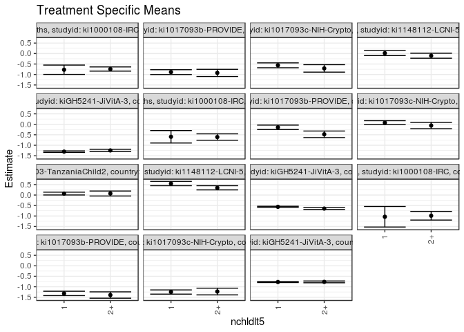

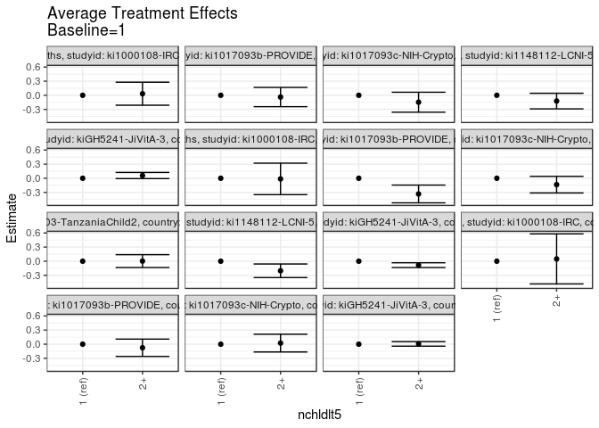

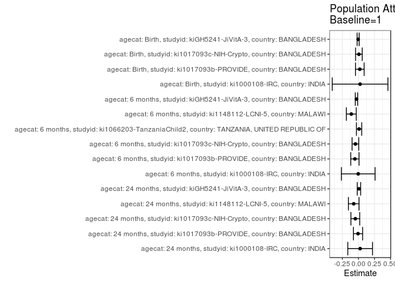

## Results Table

### Parameter: TSM

| agecat | studyid | country | intervention_level | baseline_level | estimate | ci_lower | ci_upper |
| --- | --- | --- | --- | --- | --- | --- | --- |
| Birth | ki1000108-IRC | INDIA | 1 | NA | -1.0363579 | -1.5271078 | -0.5456081 |
| Birth | ki1000108-IRC | INDIA | 2+ | NA | -0.9873614 | -1.1948193 | -0.7799035 |
| Birth | ki1017093b-PROVIDE | BANGLADESH | 1 | NA | -1.3196969 | -1.4249954 | -1.2143984 |
| Birth | ki1017093b-PROVIDE | BANGLADESH | 2+ | NA | -1.3953842 | -1.5465766 | -1.2441917 |
| Birth | ki1017093c-NIH-Crypto | BANGLADESH | 1 | NA | -1.2513215 | -1.3510500 | -1.1515931 |
| Birth | ki1017093c-NIH-Crypto | BANGLADESH | 2+ | NA | -1.2281038 | -1.3883708 | -1.0678368 |
| Birth | kiGH5241-JiVitA-3 | BANGLADESH | 1 | NA | -0.7734482 | -0.7992954 | -0.7476010 |
| Birth | kiGH5241-JiVitA-3 | BANGLADESH | 2+ | NA | -0.7677110 | -0.8098483 | -0.7255736 |
| 6 months | ki1000108-IRC | INDIA | 1 | NA | -0.5954608 | -0.8928105 | -0.2981111 |
| 6 months | ki1000108-IRC | INDIA | 2+ | NA | -0.6089080 | -0.7620137 | -0.4558022 |
| 6 months | ki1017093b-PROVIDE | BANGLADESH | 1 | NA | -0.1438744 | -0.2493382 | -0.0384106 |
| 6 months | ki1017093b-PROVIDE | BANGLADESH | 2+ | NA | -0.4773857 | -0.6331978 | -0.3215735 |
| 6 months | ki1017093c-NIH-Crypto | BANGLADESH | 1 | NA | 0.0767632 | -0.0180919 | 0.1716183 |
| 6 months | ki1017093c-NIH-Crypto | BANGLADESH | 2+ | NA | -0.0587510 | -0.2084759 | 0.0909739 |
| 6 months | ki1066203-TanzaniaChild2 | TANZANIA, UNITED REPUBLIC OF | 1 | NA | 0.0701341 | 0.0031028 | 0.1371653 |
| 6 months | ki1066203-TanzaniaChild2 | TANZANIA, UNITED REPUBLIC OF | 2+ | NA | 0.0728632 | -0.0458421 | 0.1915685 |
| 6 months | ki1148112-LCNI-5 | MALAWI | 1 | NA | 0.5489159 | 0.4449868 | 0.6528450 |
| 6 months | ki1148112-LCNI-5 | MALAWI | 2+ | NA | 0.3456976 | 0.2458192 | 0.4455759 |
| 6 months | kiGH5241-JiVitA-3 | BANGLADESH | 1 | NA | -0.5624844 | -0.5897206 | -0.5352481 |
| 6 months | kiGH5241-JiVitA-3 | BANGLADESH | 2+ | NA | -0.6457573 | -0.6891916 | -0.6023229 |
| 24 months | ki1000108-IRC | INDIA | 1 | NA | -0.7722019 | -0.9947846 | -0.5496192 |
| 24 months | ki1000108-IRC | INDIA | 2+ | NA | -0.7384765 | -0.8385195 | -0.6384334 |
| 24 months | ki1017093b-PROVIDE | BANGLADESH | 1 | NA | -0.8864807 | -1.0014123 | -0.7715492 |
| 24 months | ki1017093b-PROVIDE | BANGLADESH | 2+ | NA | -0.9237426 | -1.0946243 | -0.7528608 |
| 24 months | ki1017093c-NIH-Crypto | BANGLADESH | 1 | NA | -0.5618312 | -0.6784659 | -0.4451966 |
| 24 months | ki1017093c-NIH-Crypto | BANGLADESH | 2+ | NA | -0.7087031 | -0.8864414 | -0.5309648 |
| 24 months | ki1148112-LCNI-5 | MALAWI | 1 | NA | 0.0188827 | -0.0979715 | 0.1357368 |
| 24 months | ki1148112-LCNI-5 | MALAWI | 2+ | NA | -0.1035183 | -0.2222289 | 0.0151922 |
| 24 months | kiGH5241-JiVitA-3 | BANGLADESH | 1 | NA | -1.3048296 | -1.3406646 | -1.2689946 |
| 24 months | kiGH5241-JiVitA-3 | BANGLADESH | 2+ | NA | -1.2466726 | -1.3017454 | -1.1915999 |

### Parameter: E(Y)

| agecat | studyid | country | intervention_level | baseline_level | estimate | ci_lower | ci_upper |
| --- | --- | --- | --- | --- | --- | --- | --- |
| Birth | ki1000108-IRC | INDIA | NA | NA | -1.0105831 | -1.1973019 | -0.8238643 |
| Birth | ki1017093b-PROVIDE | BANGLADESH | NA | NA | -1.2984586 | -1.3752758 | -1.2216415 |
| Birth | ki1017093c-NIH-Crypto | BANGLADESH | NA | NA | -1.2441513 | -1.3281130 | -1.1601897 |
| Birth | kiGH5241-JiVitA-3 | BANGLADESH | NA | NA | -0.7776666 | -0.7966629 | -0.7586703 |
| 6 months | ki1000108-IRC | INDIA | NA | NA | -0.5989297 | -0.7344491 | -0.4634104 |
| 6 months | ki1017093b-PROVIDE | BANGLADESH | NA | NA | -0.1990907 | -0.2817968 | -0.1163845 |
| 6 months | ki1017093c-NIH-Crypto | BANGLADESH | NA | NA | 0.0297622 | -0.0491685 | 0.1086930 |
| 6 months | ki1066203-TanzaniaChild2 | TANZANIA, UNITED REPUBLIC OF | NA | NA | 0.0801680 | 0.0273223 | 0.1330136 |
| 6 months | ki1148112-LCNI-5 | MALAWI | NA | NA | 0.4379655 | 0.3664533 | 0.5094777 |
| 6 months | kiGH5241-JiVitA-3 | BANGLADESH | NA | NA | -0.5932472 | -0.6127728 | -0.5737215 |
| 24 months | ki1000108-IRC | INDIA | NA | NA | -0.7458150 | -0.8368180 | -0.6548120 |
| 24 months | ki1017093b-PROVIDE | BANGLADESH | NA | NA | -0.8928670 | -0.9755153 | -0.8102187 |
| 24 months | ki1017093c-NIH-Crypto | BANGLADESH | NA | NA | -0.6103502 | -0.7050157 | -0.5156847 |
| 24 months | ki1148112-LCNI-5 | MALAWI | NA | NA | -0.0547297 | -0.1370054 | 0.0275459 |
| 24 months | kiGH5241-JiVitA-3 | BANGLADESH | NA | NA | -1.2972908 | -1.3206179 | -1.2739638 |

### Parameter: ATE

| agecat | studyid | country | intervention_level | baseline_level | estimate | ci_lower | ci_upper |
| --- | --- | --- | --- | --- | --- | --- | --- |
| Birth | ki1000108-IRC | INDIA | 1 | 1 | 0.0000000 | 0.0000000 | 0.0000000 |
| Birth | ki1000108-IRC | INDIA | 2+ | 1 | 0.0489965 | -0.4826669 | 0.5806599 |
| Birth | ki1017093b-PROVIDE | BANGLADESH | 1 | 1 | 0.0000000 | 0.0000000 | 0.0000000 |
| Birth | ki1017093b-PROVIDE | BANGLADESH | 2+ | 1 | -0.0756872 | -0.2595150 | 0.1081405 |
| Birth | ki1017093c-NIH-Crypto | BANGLADESH | 1 | 1 | 0.0000000 | 0.0000000 | 0.0000000 |
| Birth | ki1017093c-NIH-Crypto | BANGLADESH | 2+ | 1 | 0.0232177 | -0.1654451 | 0.2118806 |
| Birth | kiGH5241-JiVitA-3 | BANGLADESH | 1 | 1 | 0.0000000 | 0.0000000 | 0.0000000 |
| Birth | kiGH5241-JiVitA-3 | BANGLADESH | 2+ | 1 | 0.0057372 | -0.0428429 | 0.0543173 |
| 6 months | ki1000108-IRC | INDIA | 1 | 1 | 0.0000000 | 0.0000000 | 0.0000000 |
| 6 months | ki1000108-IRC | INDIA | 2+ | 1 | -0.0134472 | -0.3482479 | 0.3213535 |
| 6 months | ki1017093b-PROVIDE | BANGLADESH | 1 | 1 | 0.0000000 | 0.0000000 | 0.0000000 |
| 6 months | ki1017093b-PROVIDE | BANGLADESH | 2+ | 1 | -0.3335113 | -0.5220447 | -0.1449779 |
| 6 months | ki1017093c-NIH-Crypto | BANGLADESH | 1 | 1 | 0.0000000 | 0.0000000 | 0.0000000 |
| 6 months | ki1017093c-NIH-Crypto | BANGLADESH | 2+ | 1 | -0.1355142 | -0.3120751 | 0.0410467 |
| 6 months | ki1066203-TanzaniaChild2 | TANZANIA, UNITED REPUBLIC OF | 1 | 1 | 0.0000000 | 0.0000000 | 0.0000000 |
| 6 months | ki1066203-TanzaniaChild2 | TANZANIA, UNITED REPUBLIC OF | 2+ | 1 | 0.0027291 | -0.1336896 | 0.1391478 |
| 6 months | ki1148112-LCNI-5 | MALAWI | 1 | 1 | 0.0000000 | 0.0000000 | 0.0000000 |
| 6 months | ki1148112-LCNI-5 | MALAWI | 2+ | 1 | -0.2032183 | -0.3473963 | -0.0590403 |
| 6 months | kiGH5241-JiVitA-3 | BANGLADESH | 1 | 1 | 0.0000000 | 0.0000000 | 0.0000000 |
| 6 months | kiGH5241-JiVitA-3 | BANGLADESH | 2+ | 1 | -0.0832729 | -0.1337935 | -0.0327524 |
| 24 months | ki1000108-IRC | INDIA | 1 | 1 | 0.0000000 | 0.0000000 | 0.0000000 |
| 24 months | ki1000108-IRC | INDIA | 2+ | 1 | 0.0337254 | -0.2105553 | 0.2780060 |
| 24 months | ki1017093b-PROVIDE | BANGLADESH | 1 | 1 | 0.0000000 | 0.0000000 | 0.0000000 |
| 24 months | ki1017093b-PROVIDE | BANGLADESH | 2+ | 1 | -0.0372618 | -0.2418289 | 0.1673053 |
| 24 months | ki1017093c-NIH-Crypto | BANGLADESH | 1 | 1 | 0.0000000 | 0.0000000 | 0.0000000 |
| 24 months | ki1017093c-NIH-Crypto | BANGLADESH | 2+ | 1 | -0.1468719 | -0.3591222 | 0.0653784 |
| 24 months | ki1148112-LCNI-5 | MALAWI | 1 | 1 | 0.0000000 | 0.0000000 | 0.0000000 |
| 24 months | ki1148112-LCNI-5 | MALAWI | 2+ | 1 | -0.1224010 | -0.2880118 | 0.0432099 |
| 24 months | kiGH5241-JiVitA-3 | BANGLADESH | 1 | 1 | 0.0000000 | 0.0000000 | 0.0000000 |
| 24 months | kiGH5241-JiVitA-3 | BANGLADESH | 2+ | 1 | 0.0581570 | -0.0068901 | 0.1232041 |

### Parameter: PAR

| agecat | studyid | country | intervention_level | baseline_level | estimate | ci_lower | ci_upper |
| --- | --- | --- | --- | --- | --- | --- | --- |
| Birth | ki1000108-IRC | INDIA | 1 | NA | 0.0257748 | -0.4076830 | 0.4592327 |
| Birth | ki1017093b-PROVIDE | BANGLADESH | 1 | NA | 0.0212383 | -0.0462355 | 0.0887121 |
| Birth | ki1017093c-NIH-Crypto | BANGLADESH | 1 | NA | 0.0071702 | -0.0448896 | 0.0592300 |
| Birth | kiGH5241-JiVitA-3 | BANGLADESH | 1 | NA | -0.0042184 | -0.0207031 | 0.0122662 |
| 6 months | ki1000108-IRC | INDIA | 1 | NA | -0.0034690 | -0.2662173 | 0.2592793 |
| 6 months | ki1017093b-PROVIDE | BANGLADESH | 1 | NA | -0.0552163 | -0.1199422 | 0.0095097 |
| 6 months | ki1017093c-NIH-Crypto | BANGLADESH | 1 | NA | -0.0470010 | -0.0991264 | 0.0051245 |
| 6 months | ki1066203-TanzaniaChild2 | TANZANIA, UNITED REPUBLIC OF | 1 | NA | 0.0100339 | -0.0311875 | 0.0512553 |
| 6 months | ki1148112-LCNI-5 | MALAWI | 1 | NA | -0.1109504 | -0.1878421 | -0.0340588 |
| 6 months | kiGH5241-JiVitA-3 | BANGLADESH | 1 | NA | -0.0307628 | -0.0491169 | -0.0124088 |
| 24 months | ki1000108-IRC | INDIA | 1 | NA | 0.0263869 | -0.1659452 | 0.2187189 |
| 24 months | ki1017093b-PROVIDE | BANGLADESH | 1 | NA | -0.0063863 | -0.0778701 | 0.0650976 |
| 24 months | ki1017093c-NIH-Crypto | BANGLADESH | 1 | NA | -0.0485190 | -0.1170586 | 0.0200207 |
| 24 months | ki1148112-LCNI-5 | MALAWI | 1 | NA | -0.0736124 | -0.1566999 | 0.0094752 |
| 24 months | kiGH5241-JiVitA-3 | BANGLADESH | 1 | NA | 0.0075388 | -0.0191440 | 0.0342215 |